# Sesion 4

CONGLOMERADOS - MÉTODO PARTICIONANTE

CONSIDERAICONES TEORICAS: -Cluster y aglomeraicones agrupa CASOS, es una clasificacion -Los conglomerdados, es agrupar los casos segun algunas similitudes -Al mismo tiempo se puede usar vairas variables y no solo agrupamiento univariable - K-medias: se agrupa mas a un centroide. -los datos atipicos que no guarda mucha similitud genera problemas con este metodo

PAQUETES

```r
library(rio)
library(cluster)
library(plyr) # para funcion "each"
library(psych) #para hacer tablas comparadas
library(knitr) #para generar tablas html
library(kableExtra) #para generar tablas html
library(factoextra) #visualización de clusters
library(ggrepel) #para que las etiquetas de los graficos no se superpongan
library(htmltab)
library(dplyr)
```

## Ejercicio 1: Agrupar los departamentos según cobertura de servicios públicos básicos (agua, desague, electrificación)

En la siguiente base de datos tenemos los departamentos del Perú (excepto Lima y Callao) con el siguiente conjunto de variables.

#NOTA: realiar un analisis de las variables

```r
data <- import("https://github.com/DataPolitica/salidas/raw/master/Data/regiones.xlsx")
str(data)
```

```
## 'data.frame':    23 obs. of  8 variables:
##  $ region         : chr  "Amazonas" "Ancash" "Apurímac" "Arequipa" ...
##  $ poblacion      : num  379384 1083519 405759 1382730 616176 ...
##  $ pobreza        : num  47.3 23.5 42.8 9.1 51.9 52.9 18.8 46.6 40.1 4.7 ...
##  $ agua           : num  51.8 71.6 56.3 72.5 67 ...
##  $ desague        : num  36.7 56.4 36.1 65.8 45.4 ...
##  $ electrificacion: num  73.7 85.2 80.4 90 80.9 ...
##  $ esperanza_vida : num  71.7 74.9 71.4 77.1 72 ...
##  $ PBI_percapita  : num  6821 16847 14739 23097 7783 ...
```

```r
summary(data)
```

```
##     region            poblacion          pobreza           agua
##  Length:23          Min.   : 141070   Min.   : 3.90   Min.   :38.25
##  Class :character   1st Qu.: 363512   1st Qu.:13.05   1st Qu.:52.37
##  Mode  :character   Median : 813381   Median :29.50   Median :61.42
##                     Mean   : 821825   Mean   :27.96   Mean   :60.66
##                     3rd Qu.:1201394   3rd Qu.:41.45   3rd Qu.:71.86
##                     Max.   :1856809   Max.   :52.90   Max.   :75.42
##     desague      electrificacion esperanza_vida  PBI_percapita
##  Min.   :29.23   Min.   :72.13   Min.   :71.04   Min.   : 6452
##  1st Qu.:35.84   1st Qu.:77.33   1st Qu.:72.05   1st Qu.: 7432
##  Median :45.35   Median :83.86   Median :72.87   Median :10492
##  Mean   :47.55   Mean   :82.67   Mean   :73.80   Mean   :13104
##  3rd Qu.:60.49   3rd Qu.:86.51   3rd Qu.:75.11   3rd Qu.:16114
##  Max.   :71.27   Max.   :91.66   Max.   :77.70   Max.   :45472
```

### Paso 1: Asignar nombre a filas y seleccionar sólo aquellos casos sin NA´s en las variables de nuestro interés

Asignemos un nombre a cada fila (al igual que le ponemos nombre a las columnas). Esto nos ayudará más adelante durante la elaboración de los gráficos.

```r
View(data)
row.names(data)=data$region
View(data)
data = data[,-1]
#trabajar sin valores perdidos
```

### Paso 2: Calcular la distancia entre los conglomerados

Para hacer el cálculo de la distancia utilizaremos 3 variables: agua, desague y electrificación.

```r
head(data)[, c(3:5)]
```

|  | agua | desague | electrificacion |
| --- | --- | --- | --- |
| Amazonas | 51.84 | 36.69 | 73.67 |
| Ancash | 71.56 | 56.38 | 85.20 |
| Apurímac | 56.33 | 36.12 | 80.43 |
| Arequipa | 72.47 | 65.85 | 89.98 |
| Ayacucho | 66.99 | 45.35 | 80.94 |
| Cajamarca | 52.89 | 32.48 | 80.68 |

```r
dist = daisy(data[,c(3:5)], metric = "gower")
# seleccionamos las columnas de insumo
# usamos metric="gower" para estandarizar cada variable. Importante.
```

### Paso 3: Crear los conglomerados

#NOTA: el cluster.only TRUE tre solo los clusters, cuando pone FALSE te trae todo

```r
grupos = pam(dist, 2, cluster.only = T) #Le decimos que cree dos grupos o cluster
data$grupos = grupos
```

### Paso 4: Analizar descriptivamente cada grupo

Podemos hacer la comparación de cualquier variable entre los grupos haciendo uso del comando describeBy():

```r
#Opcional, para recordar las clases de Estadísitca I
# Veamos los descriptivos de la variable "Agua" (columna N° 4) entre los grupos
describeBy(data$agua, group=data$grupos, digits = 2)
```

```
##
##  Descriptive statistics by group
## group: 1
##    vars  n  mean   sd median trimmed   mad   min   max range  skew kurtosis
## X1    1 14 53.32 8.88  53.52   53.44 11.09 38.25 66.99 28.74 -0.05    -1.31
##      se
## X1 2.37
## ------------------------------------------------------------
## group: 2
##    vars n  mean   sd median trimmed  mad   min   max range skew kurtosis   se
## X1    1 9 72.08 2.12  72.42   72.08 1.28 68.39 75.42  7.03 -0.3    -0.99 0.71
```

```r
# Veamos los descriptivos de la variable "Desague" (columna N° 5) entre los grupos
describeBy(data$desague, group=data$grupos, digits = 2)
```

```
##
##  Descriptive statistics by group
## group: 1
##    vars  n  mean  sd median trimmed  mad   min   max range skew kurtosis   se
## X1    1 14 37.14 6.2   36.2   36.82 6.03 29.23 48.88 19.65 0.55    -0.99 1.66
## ------------------------------------------------------------
## group: 2
##    vars n  mean   sd median trimmed  mad   min   max range  skew kurtosis   se
## X1    1 9 63.74 6.55  65.85   63.74 6.32 52.82 71.27 18.45 -0.35    -1.56 2.18
```

```r
# Veamos los descriptivos de la variable "Electrificacion" (columna N° 6) entre los grupos
describeBy(data$electrificacion, group=data$grupos, digits = 2)
```

```
##
##  Descriptive statistics by group
## group: 1
##    vars  n  mean   sd median trimmed mad   min   max range skew kurtosis   se
## X1    1 14 79.06 4.55  78.94   79.03 5.4 72.13 86.33  14.2 0.12    -1.39 1.22
## ------------------------------------------------------------
## group: 2
##    vars n  mean   sd median trimmed  mad  min   max range  skew kurtosis   se
## X1    1 9 88.28 2.48  89.11   88.28 3.59 85.2 91.66  6.46 -0.06     -1.9 0.83
```

#NOTA: Revisrar el R consola siempre

```r
describeBy(as.matrix(cbind(data[,c(4:6)])), group=data$grupos, digits = 2)
```

```
##
##  Descriptive statistics by group
## INDICES: 1
##                 vars  n  mean   sd median trimmed  mad   min   max range skew
## desague            1 14 37.14 6.20  36.20   36.82 6.03 29.23 48.88 19.65 0.55
## electrificacion    2 14 79.06 4.55  78.94   79.03 5.40 72.13 86.33 14.20 0.12
## esperanza_vida     3 14 72.46 1.10  72.32   72.37 1.07 71.04 74.96  3.92 0.77
##                 kurtosis   se
## desague            -0.99 1.66
## electrificacion    -1.39 1.22
## esperanza_vida     -0.38 0.29
## ------------------------------------------------------------
## INDICES: 2
##                 vars n  mean   sd median trimmed  mad   min   max range  skew
## desague            1 9 63.74 6.55  65.85   63.74 6.32 52.82 71.27 18.45 -0.35
## electrificacion    2 9 88.28 2.48  89.11   88.28 3.59 85.20 91.66  6.46 -0.06
## esperanza_vida     3 9 75.88 1.51  76.52   75.88 1.75 72.87 77.70  4.83 -0.62
##                 kurtosis   se
## desague            -1.56 2.18
## electrificacion    -1.90 0.83
## esperanza_vida     -0.90 0.50
```

También usar aggregate() para crear una nueva base que sean los resultados: #NOTA: el aggegate es para crear un nuev objeto, toma de referencia un nivel de una variable (por ejemplo nivel 1 y 2), a esto le hace una operación matemática.

```r
aggregate(as.matrix(cbind(data[,c(3:5)]))~ grupos, data=data,
          mean)
```

| grupos | agua | desague | electrificacion |
| --- | --- | --- | --- |
| 1 | 53.32429 | 37.13857 | 79.05929 |
| 2 | 72.08111 | 63.74000 | 88.27667 |

```r
#Guardamos la visualización en un data.frame
tabla = aggregate(as.matrix(cbind(data[,c(3:5)]))~ grupos, data=data,
         mean)
#tranponer: trasladar de filas a columnas
tabla = t(as.data.frame(tabla))
tabla
```

```
##                     [,1]     [,2]
## grupos           1.00000  2.00000
## agua            53.32429 72.08111
## desague         37.13857 63.74000
## electrificacion 79.05929 88.27667
```

Podemos guardar en formato amigable

```r
tablahtml = kable(tabla, format = "html", digits = 2)

kable_styling(tablahtml)
```

| grupos | 1.00 | 2.00 |
| --- | --- | --- |
| agua | 53.32 | 72.08 |
| desague | 37.14 | 63.74 |
| electrificacion | 79.06 | 88.28 |

### Paso 5: Visualización de grupos en un gráfico

También podemos visualizar el agrupamiento de los departamentos.

Podemos cambiar el nombre de los grupos de acuerdo a lo que hemos visto en la parte descriptiva:

```r
data$grupos = as.factor(data$grupos)
str(data$grupos)
```

```
##  Factor w/ 2 levels "1","2": 1 2 1 2 1 1 1 1 1 2 ...
```

```r
levels(data$grupos) = c("Baja cobertura", "Alta cobertura")
table(data$grupos)
```

```
##
## Baja cobertura Alta cobertura
##             14              9
```

Generamos nuestro primer gráfico

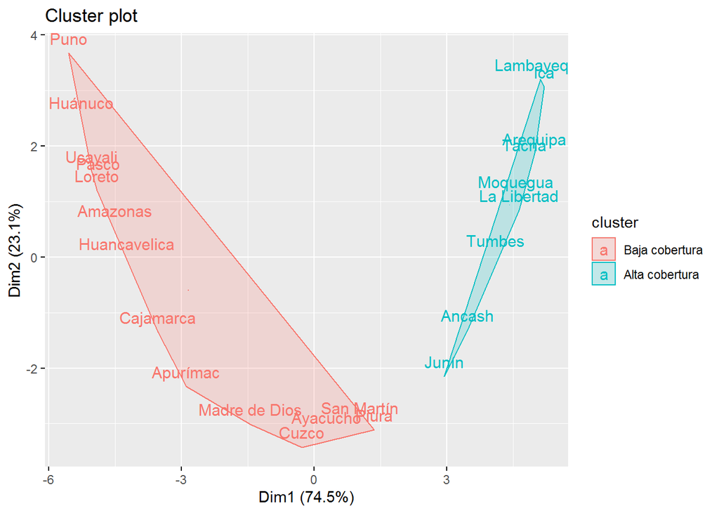

```r
fviz_cluster(object = list(data=dist, cluster = data$grupos),
             geom = c("text"),
             ellipse.type = "convex")
```

Mejoramos el gráfico:

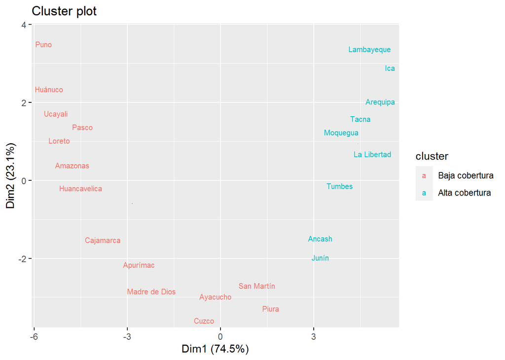

```r
fviz_cluster(object = list(data=dist, cluster = data$grupos),
             geom = c("text"),
             ellipse = FALSE, labelsize = 8,
             repel = T)
```

```r
# Decimos que elimine el elipse, cambiamos el nombre de la etiqueta y decimos que no se superpongan las etiquetas.
```

##Ejercicio 2 Nos piden que agrupemos a los distritos del Perú en función de su sistema político. Para eso, nos valeremos de algunos indicadores como: NEP: Número efectivo de partidos NP: Número de partidos Hiperfraccionamiento: Indicador de hiperfraccionamiento Volatilidad total: Indicador de volatilidad electoral Concentracción: Indicador de concentración Herfindal Hirschman: Indicador de concentración de Herfindal-hirchman Competitividad: Indicador de competitividad

```r
sispol <- import("https://github.com/JairAlva/Estadistica-II/raw/master/Clase%204/ERM2010_ISP_Distrital.xlsx")
str(sispol)
```

```
## 'data.frame':    1639 obs. of  11 variables:
##  $ UBIGEO                   : chr  "010102" "010103" "010104" "010105" ...
##  $ REGION                   : chr  "AMAZONAS" "AMAZONAS" "AMAZONAS" "AMAZONAS" ...
##  $ PROVINCIA                : chr  "CHACHAPOYAS" "CHACHAPOYAS" "CHACHAPOYAS" "CHACHAPOYAS" ...
##  $ DISTRITO                 : chr  "ASUNCION" "BALSAS" "CHETO" "CHILIQUIN" ...
##  $ NEP 2010                 : num  2.29 2.46 3.43 3.41 4.58 ...
##  $ NP 2010                  : num  1.47 1.74 3.14 1.98 3.87 ...
##  $ HIPERFRACCIONAMIENTO 2010: num  2.59 2.68 3.62 4.05 5.21 ...
##  $ VOLATILIDAD TOTAL 2010   : num  0.002 1 1 0.033 0.071 0.027 0.125 0.105 0.017 0.019 ...
##  $ CONCENTRACION 2010       : num  0.841 0.85 0.659 0.649 0.566 0.787 0.562 0.341 0.423 0.582 ...
##  $ HERFINDHAL HIRSCHMAN 2010: num  0.436 0.407 0.291 0.293 0.219 0.34 0.215 0.134 0.175 0.242 ...
##  $ COMPETITIVIDAD 2010      : num  0.338 0.216 0.002 0.265 0.005 0.124 0.162 0.039 0.049 0.035 ...
```

```r
summary(sispol)
```

```
##     UBIGEO             REGION           PROVINCIA           DISTRITO
##  Length:1639        Length:1639        Length:1639        Length:1639
##  Class :character   Class :character   Class :character   Class :character
##  Mode  :character   Mode  :character   Mode  :character   Mode  :character
##
##
##
##     NEP 2010         NP 2010      HIPERFRACCIONAMIENTO 2010
##  Min.   : 0.000   Min.   :0.000   Min.   : 0.000
##  1st Qu.: 3.224   1st Qu.:2.381   1st Qu.: 3.688
##  Median : 4.062   Median :3.076   Median : 4.723
##  Mean   : 4.261   Mean   :3.263   Mean   : 4.943
##  3rd Qu.: 5.146   3rd Qu.:3.990   3rd Qu.: 5.989
##  Max.   :11.074   Max.   :8.787   Max.   :14.042
##  VOLATILIDAD TOTAL 2010 CONCENTRACION 2010 HERFINDHAL HIRSCHMAN 2010
##  Min.   :0.0000         Min.   :0.0000     Min.   :0.000
##  1st Qu.:0.0710         1st Qu.:0.5070     1st Qu.:0.194
##  Median :0.1340         Median :0.6040     Median :0.246
##  Mean   :0.2062         Mean   :0.6221     Mean   :0.263
##  3rd Qu.:0.2135         3rd Qu.:0.7195     3rd Qu.:0.310
##  Max.   :1.0000         Max.   :1.0000     Max.   :1.000
##  COMPETITIVIDAD 2010
##  Min.   :0.00000
##  1st Qu.:0.03100
##  Median :0.07100
##  Mean   :0.09586
##  3rd Qu.:0.13150
##  Max.   :1.00000
```

Calculamos la distancia entre cada unidad de análisis

```r
dist = daisy(sispol[,c(5:11)], metric = "gower")
```

Proponemos agrupar a los distritos en 4 grupos

```r
grupos = pam(dist, 4, cluster.only = F)
grupos$clustering
```

```
##    1    2    3    4    5    6    7    8    9   10   11   12   13   14   15   16
##    1    2    2    3    3    1    3    4    4    3    3    2    2    3    2    4
##   17   18   19   20   21   22   23   24   25   26   27   28   29   30   31   32
##    2    2    4    2    4    3    4    3    4    3    2    2    1    4    1    2
##   33   34   35   36   37   38   39   40   41   42   43   44   45   46   47   48
##    3    2    4    1    2    2    3    2    1    2    2    1    2    3    2    2
##   49   50   51   52   53   54   55   56   57   58   59   60   61   62   63   64
##    3    4    3    2    2    3    2    3    2    2    1    4    1    1    1    1
##   65   66   67   68   69   70   71   72   73   74   75   76   77   78   79   80
##    1    4    1    1    3    4    4    4    4    3    3    1    4    3    3    1
##   81   82   83   84   85   86   87   88   89   90   91   92   93   94   95   96
##    3    1    2    3    3    3    3    3    3    3    4    4    1    4    4    4
##   97   98   99  100  101  102  103  104  105  106  107  108  109  110  111  112
##    4    2    1    3    3    4    1    3    1    1    4    3    1    3    4    4
##  113  114  115  116  117  118  119  120  121  122  123  124  125  126  127  128
```

[output cut: 191 more lines]

```r
sispol$clusterP = grupos$clustering
```

Podemos explorar los resultados

```r
#Opcional, para recordar las clases de Estadísitca I
describeBy(as.matrix(cbind(sispol[,c(5:11)])), group=sispol$clusterP, digits = 2)
```

```
##
##  Descriptive statistics by group
## INDICES: 1
##                           vars   n mean   sd median trimmed  mad  min  max
## NEP 2010                     1 412 2.78 0.46   2.88    2.81 0.50 1.00 3.54
## NP 2010                      2 412 2.10 0.41   2.12    2.11 0.47 1.00 2.94
## HIPERFRACCIONAMIENTO 2010    3 412 3.22 0.66   3.29    3.24 0.64 1.00 5.30
## VOLATILIDAD TOTAL 2010       4 412 0.15 0.10   0.13    0.14 0.10 0.00 0.55
## CONCENTRACION 2010           5 412 0.80 0.09   0.78    0.79 0.09 0.64 1.00
## HERFINDHAL HIRSCHMAN 2010    6 412 0.37 0.08   0.35    0.36 0.06 0.28 1.00
## COMPETITIVIDAD 2010          7 412 0.15 0.12   0.12    0.13 0.11 0.00 1.00
##                           range  skew kurtosis   se
## NEP 2010                   2.54 -0.55    -0.44 0.02
## NP 2010                    1.94 -0.23    -0.66 0.02
## HIPERFRACCIONAMIENTO 2010  4.30 -0.20    -0.27 0.03
## VOLATILIDAD TOTAL 2010     0.55  0.85     0.45 0.01
## CONCENTRACION 2010         0.36  0.66    -0.59 0.00
## HERFINDHAL HIRSCHMAN 2010  0.72  2.16    11.28 0.00
## COMPETITIVIDAD 2010        1.00  1.69     6.40 0.01
## ------------------------------------------------------------
## INDICES: 2
##                           vars   n mean   sd median trimmed  mad  min  max
## NEP 2010                     1 126 3.05 0.84   3.00    3.01 0.83 1.00 5.08
## NP 2010                      2 126 2.38 0.68   2.33    2.35 0.72 1.00 4.38
## HIPERFRACCIONAMIENTO 2010    3 126 3.38 1.03   3.46    3.30 0.93 1.00 6.64
## VOLATILIDAD TOTAL 2010       4 126 1.00 0.00   1.00    1.00 0.00 1.00 1.00
## CONCENTRACION 2010           5 126 0.76 0.14   0.74    0.76 0.16 0.47 1.00
## HERFINDHAL HIRSCHMAN 2010    6 126 0.36 0.11   0.33    0.35 0.09 0.20 1.00
## COMPETITIVIDAD 2010          7 126 0.14 0.13   0.10    0.12 0.09 0.00 1.00
##                           range skew kurtosis   se
## NEP 2010                   4.08 0.34    -0.31 0.08
## NP 2010                    3.38 0.37    -0.21 0.06
## HIPERFRACCIONAMIENTO 2010  5.64 0.65     0.53 0.09
## VOLATILIDAD TOTAL 2010     0.00  NaN      NaN 0.00
## CONCENTRACION 2010         0.53 0.19    -0.98 0.01
## HERFINDHAL HIRSCHMAN 2010  0.80 1.77     6.76 0.01
## COMPETITIVIDAD 2010        1.00 2.70    12.05 0.01
## ------------------------------------------------------------
## INDICES: 3
##                           vars   n mean   sd median trimmed  mad min  max range
```

[output cut: 18 more lines]

```
## NEP 2010                     1 502 5.97 0.95   5.75    5.85 0.81 4.69 11.07
## NP 2010                      2 502 4.68 0.88   4.46    4.60 0.75 2.62  8.79
## HIPERFRACCIONAMIENTO 2010    3 502 6.93 1.25   6.72    6.79 1.15 4.85 14.04
## VOLATILIDAD TOTAL 2010       4 502 0.15 0.12   0.13    0.14 0.09 0.00  1.00
## CONCENTRACION 2010           5 502 0.46 0.05   0.47    0.46 0.06 0.28  0.58
## HERFINDHAL HIRSCHMAN 2010    6 502 0.17 0.02   0.17    0.17 0.03 0.09  0.21
## COMPETITIVIDAD 2010          7 502 0.05 0.04   0.04    0.05 0.04 0.00  0.23
##                           range  skew kurtosis   se
## NEP 2010                   6.38  1.37     2.52 0.04
## NP 2010                    6.17  1.04     2.02 0.04
## HIPERFRACCIONAMIENTO 2010  9.19  1.25     2.54 0.06
## VOLATILIDAD TOTAL 2010     1.00  3.49    20.60 0.01
## CONCENTRACION 2010         0.30 -0.42    -0.34 0.00
## HERFINDHAL HIRSCHMAN 2010  0.12 -0.55    -0.28 0.00
## COMPETITIVIDAD 2010        0.23  1.30     1.88 0.00
```

```r
aggregate(as.matrix(cbind(sispol[,c(5:11)]))~ clusterP, data=sispol,
          FUN=each(MD = median, Media = mean))
```

[output not shown]

```r
#Guardamos la visualización en un data.frame
tabla = aggregate(as.matrix(cbind(sispol[,c(5:11)]))~ clusterP, data=sispol,
          FUN=each(MD = median, Media = mean))

tabla = t(as.data.frame(tabla))
tabla
```

```
##                                      [,1]      [,2]       [,3]       [,4]
## clusterP                        1.0000000 2.0000000 3.00000000 4.00000000
## NEP 2010.MD                     2.8765000 2.9970000 4.07100000 5.74700000
## NEP 2010.Media                  2.7835777 3.0502778 4.09790317 5.97060757
## NP 2010.MD                      2.1220000 2.3310000 3.08800000 4.45950000
## NP 2010.Media                   2.0980194 2.3796905 3.06317195 4.67793028
## HIPERFRACCIONAMIENTO 2010.MD    3.2875000 3.4590000 4.74300000 6.72050000
## HIPERFRACCIONAMIENTO 2010.Media 3.2245971 3.3767778 4.78837563 6.93182470
## VOLATILIDAD TOTAL 2010.MD       0.1325000 1.0000000 0.11000000 0.13100000
## VOLATILIDAD TOTAL 2010.Media    0.1460437 1.0000000 0.12760601 0.15010359
## CONCENTRACION 2010.MD           0.7780000 0.7425000 0.60400000 0.46800000
## CONCENTRACION 2010.Media        0.8029684 0.7591587 0.60522705 0.45938845
## HERFINDHAL HIRSCHMAN 2010.MD    0.3475000 0.3340000 0.24600000 0.17400000
## HERFINDHAL HIRSCHMAN 2010.Media 0.3711529 0.3560159 0.24599666 0.17117331
## COMPETITIVIDAD 2010.MD          0.1200000 0.0990000 0.07700000 0.04150000
## COMPETITIVIDAD 2010.Media       0.1463277 0.1381349 0.08911352 0.05188446
```

Podemos guardar en formato amigable

```r
tablahtml = kable(tabla, format = "html", digits = 2)

kable_styling(tablahtml)
```

| clusterP | 1.00 | 2.00 | 3.00 | 4.00 |
| --- | --- | --- | --- | --- |
| NEP 2010.MD | 2.88 | 3.00 | 4.07 | 5.75 |
| NEP 2010.Media | 2.78 | 3.05 | 4.10 | 5.97 |
| NP 2010.MD | 2.12 | 2.33 | 3.09 | 4.46 |
| NP 2010.Media | 2.10 | 2.38 | 3.06 | 4.68 |
| HIPERFRACCIONAMIENTO 2010.MD | 3.29 | 3.46 | 4.74 | 6.72 |
| HIPERFRACCIONAMIENTO 2010.Media | 3.22 | 3.38 | 4.79 | 6.93 |
| VOLATILIDAD TOTAL 2010.MD | 0.13 | 1.00 | 0.11 | 0.13 |
| VOLATILIDAD TOTAL 2010.Media | 0.15 | 1.00 | 0.13 | 0.15 |
| CONCENTRACION 2010.MD | 0.78 | 0.74 | 0.60 | 0.47 |
| CONCENTRACION 2010.Media | 0.80 | 0.76 | 0.61 | 0.46 |
| HERFINDHAL HIRSCHMAN 2010.MD | 0.35 | 0.33 | 0.25 | 0.17 |
| HERFINDHAL HIRSCHMAN 2010.Media | 0.37 | 0.36 | 0.25 | 0.17 |
| COMPETITIVIDAD 2010.MD | 0.12 | 0.10 | 0.08 | 0.04 |
| COMPETITIVIDAD 2010.Media | 0.15 | 0.14 | 0.09 | 0.05 |

También podemos visualizar el agrupamiento de los distritos

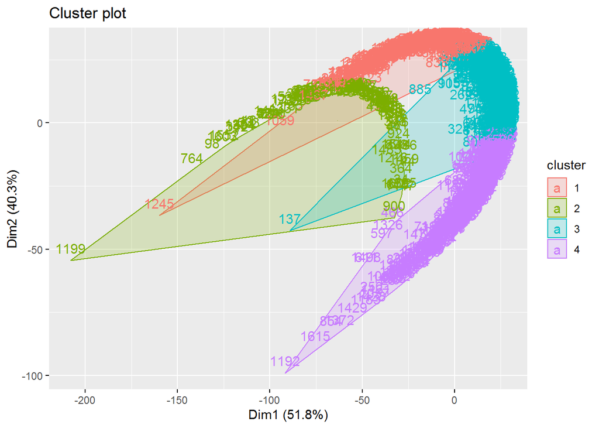

```r
fviz_cluster(object = list(data=dist, cluster = sispol$clusterP),
             geom = c("text"),
             ellipse.type = "convex")
```

Mejorar el gráfico

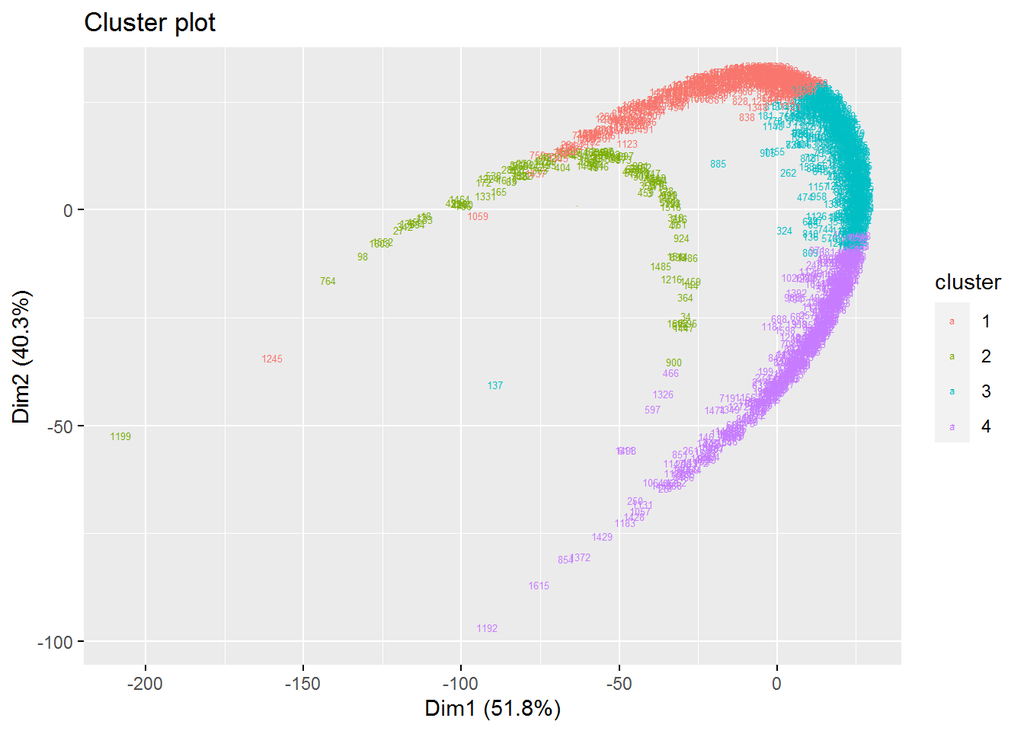

```r
fviz_cluster(object = list(data=dist, cluster = sispol$clusterP),
             geom = c("text"),
             ellipse = FALSE,labelsize = 5)
```

##Ejercicio 3 Ahora hablaremos sobre la tolerancia política en el Perú. Nos interesa explorar especificamente la tolerancia política en el Perú

```r
cultura = import("https://github.com/JairAlva/Estadistica-II/raw/master/Clase%204/Peru2019.dta")

cultura = select(cultura, d1, d2, d3, d4)
str(cultura)
```

```
## 'data.frame':    1521 obs. of  4 variables:
##  $ d1: num  6 7 8 5 9 2 2 8 6 6 ...
##   ..- attr(*, "label")= chr "Aprueba derecho de votar de los que critican la forma de gobierno"
##   ..- attr(*, "format.stata")= chr "%36.0f"
##   ..- attr(*, "labels")= Named num [1:5] 1 10 NA NA NA
##   .. ..- attr(*, "names")= chr [1:5] "Desaprueba firmemente" "Aprueba firmemente" "No sabe" "No responde" ...
##  $ d2: num  5 7 10 6 8 3 8 6 6 5 ...
##   ..- attr(*, "label")= chr "Aprueba el derecho a protestar de los critican la forma de gobierno"
##   ..- attr(*, "format.stata")= chr "%36.0f"
##   ..- attr(*, "labels")= Named num [1:5] 1 10 NA NA NA
##   .. ..- attr(*, "names")= chr [1:5] "Desaprueba firmemente" "Aprueba firmemente" "No sabe" "No responde" ...
##  $ d3: num  4 8 4 6 6 4 3 4 5 6 ...
##   ..- attr(*, "label")= chr "Aprueba el derecho a candidatizarse de los que critican la forma de gobierno"
##   ..- attr(*, "format.stata")= chr "%36.0f"
##   ..- attr(*, "labels")= Named num [1:5] 1 10 NA NA NA
##   .. ..- attr(*, "names")= chr [1:5] "Desaprueba firmemente" "Aprueba firmemente" "No sabe" "No responde" ...
##  $ d4: num  4 6 5 5 5 1 2 5 5 5 ...
##   ..- attr(*, "label")= chr "Aprueba el derecho a hacer un discurso de los que critican la forma de gobierno"
##   ..- attr(*, "format.stata")= chr "%36.0f"
##   ..- attr(*, "labels")= Named num [1:5] 1 10 NA NA NA
##   .. ..- attr(*, "names")= chr [1:5] "Desaprueba firmemente" "Aprueba firmemente" "No sabe" "No responde" ...
```

```r
cultura[,] = lapply(cultura[,], as.numeric)

cultura[!complete.cases(cultura),]
```

|  | d1 | d2 | d3 | d4 |
| --- | --- | --- | --- | --- |
| 47 | 1 | 3 | NA | 3 |
| 268 | NA | 6 | 2 | 5 |
| 269 | NA | 9 | NA | NA |
| 349 | NA | NA | NA | NA |
| 505 | NA | 10 | 2 | 2 |
| 537 | 5 | 7 | NA | NA |
| 581 | 8 | 3 | NA | 4 |
| 728 | NA | NA | NA | NA |
| 766 | NA | NA | NA | 10 |
| 845 | NA | NA | NA | NA |

[output cut: 22 more lines]

```r
cultura = cultura[complete.cases(cultura),]
```

Calculamos la distancia entre cada unidad de análisis

```r
distA = daisy(cultura, metric = "gower")
```

Proponemos una cantidad “n” de grupos a formar

```r
gruposA = pam(distA, 2, cluster.only = T)

cultura$clusterP = gruposA
```

Podemos explorar los resultados

```r
#Opcional, para recordar las clases de Estadísitca I
describeBy(as.matrix(cbind(cultura[,c(1:4)])), group=cultura$clusterP, digits = 2)
```

```
##
##  Descriptive statistics by group
## INDICES: 1
##    vars   n mean   sd median trimmed  mad min max range skew kurtosis   se
## d1    1 707 4.77 2.25      5    4.64 1.48   1  10     9 0.45    -0.05 0.08
## d2    2 707 5.30 2.29      5    5.22 1.48   1  10     9 0.31    -0.38 0.09
## d3    3 707 3.17 1.60      3    3.10 1.48   1  10     9 0.68     1.22 0.06
## d4    4 707 3.20 1.72      3    3.07 1.48   1  10     9 0.88     1.56 0.06
## ------------------------------------------------------------
## INDICES: 2
##    vars   n mean   sd median trimmed  mad min max range  skew kurtosis   se
## d1    1 782 7.02 2.07      7    7.16 1.48   1  10     9 -0.56     0.29 0.07
## d2    2 782 7.69 1.82      8    7.84 1.48   1  10     9 -0.55     0.07 0.06
## d3    3 782 6.23 1.95      6    6.21 1.48   1  10     9 -0.04     0.12 0.07
## d4    4 782 6.57 1.97      6    6.55 1.48   1  10     9  0.06    -0.36 0.07
```

```r
aggregate(as.matrix(cbind(cultura[,c(1:4)]))~ clusterP, data=cultura,
          FUN=plyr::each(MD = median, Media = mean))
```

[output not shown]

```r
#Guardamos la visualización en un data.frame
tablaA = aggregate(as.matrix(cbind(cultura[,c(1:4)]))~ clusterP, data=cultura,
          FUN=plyr::each(MD = median, Media = mean))

tablaA = t(as.data.frame(tablaA))
tablaA
```

```
##              [,1]     [,2]
## clusterP 1.000000 2.000000
## d1.MD    5.000000 7.000000
## d1.Media 4.766620 7.016624
## d2.MD    5.000000 8.000000
## d2.Media 5.299859 7.693095
## d3.MD    3.000000 6.000000
## d3.Media 3.169731 6.230179
## d4.MD    3.000000 6.000000
## d4.Media 3.196605 6.572890
```

Podemos guardar en formato amigable

```r
tablahtml = kable(tablaA, format = "html", digits = 2)
kable_styling(tablahtml)
```

| clusterP | 1.00 | 2.00 |
| --- | --- | --- |
| d1.MD | 5.00 | 7.00 |
| d1.Media | 4.77 | 7.02 |
| d2.MD | 5.00 | 8.00 |
| d2.Media | 5.30 | 7.69 |
| d3.MD | 3.00 | 6.00 |
| d3.Media | 3.17 | 6.23 |
| d4.MD | 3.00 | 6.00 |
| d4.Media | 3.20 | 6.57 |

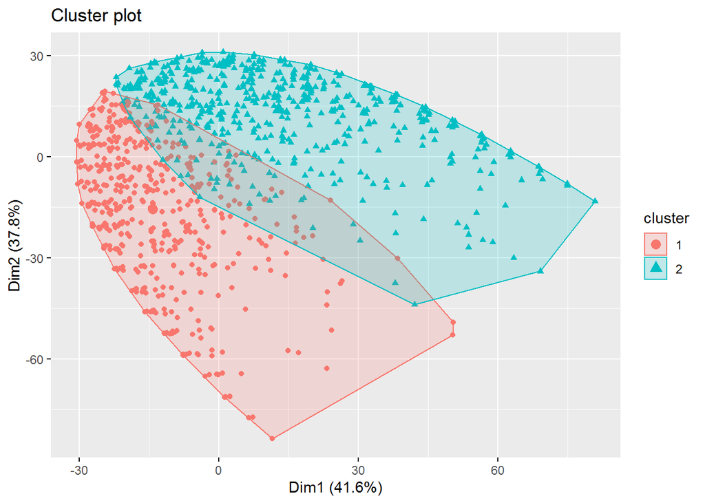

```r
fviz_cluster(object = list(data=distA, cluster = cultura$clusterP),
             geom = c("point"),
             ellipse.type = "convex")
```

Mejorar el gráfico

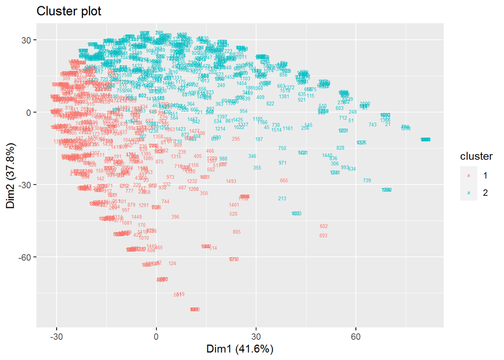

```r
fviz_cluster(object = list(data=distA, cluster = cultura$clusterP),
             geom = c("text"),
             ellipse = FALSE,labelsize = 5)
```